# Analiza wizualizacji w mediach

Michał Pytel

2023-11-05

**Cel raportu:** Znalezienie wizualizacji dostępnej w prasie, telewizji lub internecie, opublikowanej w ostatnim czasie, tj. nie wcześniej niż 15.10.2023r.

## Wizualizacja źródłowa

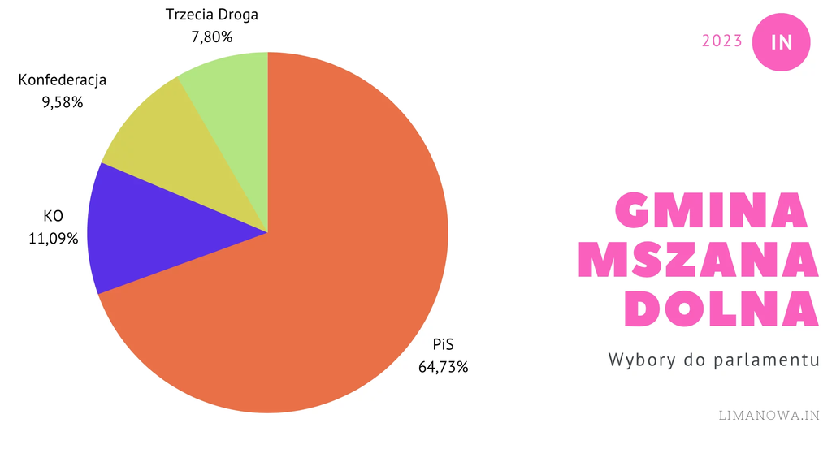

**Źródło:** https://limanowa.in/aktualnosci/wyniki-wyborow-w-miescie-i-gminie-mszana-dolna/68285

**Data publikacji:** 16 październik 2023

## Uzasadnienie dlaczego wykres jest zły

- **Wykres kołowy:** Ludzie mają problem z otczytaniem małych różnic z wykresu kołowego. W tym przypadku na pierwszy rzut oka widzimy, że partia PiS zdobyła najwięcej głosów. Dla reszty jest to gorzej widoczne, ponieważ gdyby nie było etykiet z dokładnymi wartościami to trudno by było stwierdzić, która z nich ma najwięcej, a która najmniej
- **Wartości powinny sie sumować do 100%,** ale tak nie jest, jeżeli policzymy ile jest w sumie to wyjdzie **zaledwie 93,2%**. To co się stało z resztą, wynika z niedoparzenia autora tego wykresu, który zapomniał dodać jeszcze aż 3 inne partie. To oznacza, że proporcje z podanymi procentowo są błędne i nie odzwierdciedlają tego samego.
- **Mylące kolory:** Kolory konfederacji i Trzeciej Drogi są bardzo podobne i się zlewają

## Moja propozycja poprawy wizualizacji

W celu poprawy wizualizacji wykorzystałem oficjalną ramkę danych z danymi do głosowania ze strony: https://wybory.gov.pl/sejmsenat2023/pl/dane_w_arkuszach

Tutaj jest link do pobrania ramki danych, której użyłem: https://wybory.gov.pl/sejmsenat2023/data/csv/wyniki_gl_na_listy_po_gminach_sejm_csv.zip

```r
library(dplyr)
```

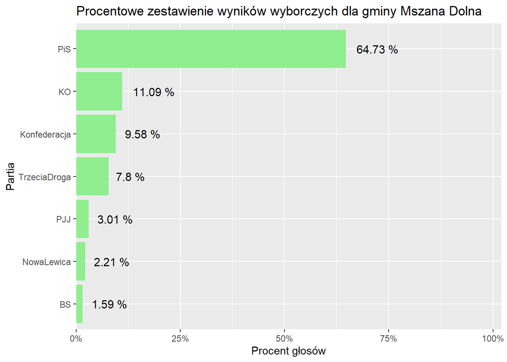

```r
library(ggplot2)
library(tidyr)
df <- read.csv2("wyniki_gl_na_listy_po_gminach_sejm_utf8.csv")

glosy_ilosciowo <- df %>%
  filter(Gmina == "gm. Mszana Dolna") %>%
  mutate(PiS = KOMITET.WYBORCZY.PRAWO.I.SPRAWIEDLIWOŚĆ,
         KO = KOALICYJNY.KOMITET.WYBORCZY.KOALICJA.OBYWATELSKA.PO..N.IPL.ZIELONI,
         Konfederacja = KOMITET.WYBORCZY.KONFEDERACJA.WOLNOŚĆ.I.NIEPODLEGŁOŚĆ,
         NowaLewica = KOMITET.WYBORCZY.NOWA.LEWICA,
         TrzeciaDroga = KOALICYJNY.KOMITET.WYBORCZY.TRZECIA.DROGA.POLSKA.2050.SZYMONA.HOŁOWNI...POLSKIE.STRONNICTWO.LUDOWE,
         PJJ = KOMITET.WYBORCZY.POLSKA.JEST.JEDNA,
         BS = KOMITET.WYBORCZY.BEZPARTYJNI.SAMORZĄDOWCY) %>%
  select(PiS, KO, Konfederacja, TrzeciaDroga, NowaLewica, PJJ, BS) %>%
  pivot_longer(
    cols = c(PiS, KO, Konfederacja, TrzeciaDroga, NowaLewica, PJJ, BS),
    names_to = "Partia",
    values_to = "Liczba_głosów")

suma <- glosy_ilosciowo %>%
  summarize(suma = sum(Liczba_głosów))
suma = as.integer(suma)

glosy_procentowo <- glosy_ilosciowo %>%
  mutate(Procent_glosow = round((Liczba_głosów / suma) * 100, digits = 2)) %>%
  mutate(Partia = forcats::fct_reorder(Partia, Procent_glosow)) %>%
  ggplot(aes(y = Partia, x = Procent_glosow)) +
  scale_fill_identity()+
  geom_col(fill = "lightgreen") +
  scale_x_continuous(labels=scales::percent_format(scale=1), limits = c(0,100), expand = c(0, 0, 0,2))+
  geom_text(aes(label = paste(Procent_glosow, "%")), hjust = -0.25, vjust = 0.5, size = 4) +  # Dodawanie wartości procentowych
  labs(title = "Procentowe zestawienie wyników wyborczych dla gminy Mszana Dolna",
       x = "Procent głosów",
       y = "Partia")

glosy_procentowo
```

## Dlaczego ten wykres jest lepszy?

- Wszystkie partie, które były w danych są na nim uwzględnione, (*suma procentów to w przybliżeniu 100%*)
- Widać dobrze różnicę między małymi różnicami w danych *(np. między KO , a Konfederacją)*
- Widoczny tytuł i opis osi

**Przede wszystkim poprawnie opisuje dane**